# General extenders in Irish English

Anonymous

2022-06-09

# 1 Introducion

This document shows an analysis of general extenders in Irish English based on the Irish component of the International Corpus of English (ICE).

# 2 Preparation

Install packages

```r
install.packages("tidyverse")
install.packages("quanteda")
install.packages("readtext")
install.packages("plyr")
install.packages("Boruta")
install.packages("ggparty")
install.packages("party")
install.packages("partykit")
install.packages("partykit")
```

Load packages

Set options

Define paths to corpus and biodata

```r
# load packages
library(tidyverse)
library(quanteda)
library(readtext)
library(here)
# set options
options(stringsAsFactors = F)
options(scipen = 999)
options(max.print=10000)
# define image directory
imageDirectory<-"images"
# specify paths
cpath <- "D:\\Uni\\Korpora\\Original\\ICE Ireland version 1.2.2\\ICE-Ireland txt\\ICE spoken running txt"
biopath <- "D:\\Uni\\Korpora\\Metadata/BiodataIceIreland.txt"
```

# 3 Preprocessing

Create vector of corpus files.

```r
# load corpus files
cfiles = list.files(path = cpath, all.files = T,
                          full.names = T, recursive = T, ignore.case = T,
                          include.dirs = T)
# inspect files
length(cfiles); head(cfiles)
```

```
## [1] 300
```

```
## [1] "D:\\Uni\\Korpora\\Original\\ICE Ireland version 1.2.2\\ICE-Ireland txt\\ICE spoken running txt/S1A-001 Riding.txt"
## [2] "D:\\Uni\\Korpora\\Original\\ICE Ireland version 1.2.2\\ICE-Ireland txt\\ICE spoken running txt/S1A-002 Dinner chat 1.txt"
## [3] "D:\\Uni\\Korpora\\Original\\ICE Ireland version 1.2.2\\ICE-Ireland txt\\ICE spoken running txt/S1A-003 Dinner chat 2.txt"
## [4] "D:\\Uni\\Korpora\\Original\\ICE Ireland version 1.2.2\\ICE-Ireland txt\\ICE spoken running txt/S1A-004 Nursing home 1.txt"
## [5] "D:\\Uni\\Korpora\\Original\\ICE Ireland version 1.2.2\\ICE-Ireland txt\\ICE spoken running txt/S1A-005 Masons.txt"
## [6] "D:\\Uni\\Korpora\\Original\\ICE Ireland version 1.2.2\\ICE-Ireland txt\\ICE spoken running txt/S1A-006 Girls' chat 1.txt"
```

Load corpus

```r
# load corpus
cire <- readtext::readtext(cfiles) %>%
  dplyr::mutate(doc_id = stringr::str_remove_all(doc_id, " .*"),
                text = stringr::str_squish(text),
                text = stringr::str_trim(text, side = "both"))
# inspect data
str(cire);head(cire)
```

```
## Classes 'readtext' and 'data.frame': 300 obs. of  2 variables:
##  $ doc_id: chr  "S1A-001" "S1A-002" "S1A-003" "S1A-004" ...
##  $ text  : chr  "<S1A-001 Riding> <I> <S1A-001$A> <#> Well how did the riding go tonight <S1A-001$B> <#> It was good so it was <"| __truncated__ "<S1A-002 Dinner chat 1> <I> <S1A-002$A> <#> He 's been married for three years and is now <{> <[> getting divor"| __truncated__ "<S1A-003 Dinner chat 2…
```

```
## readtext object consisting of 6 documents and 0 docvars.
## # Description: df [6 × 2]
##   doc_id  text
##   <chr>   <chr>
## 1 S1A-001 "\"<S1A-001 R\"..."
## 2 S1A-002 "\"<S1A-002 D\"..."
## 3 S1A-003 "\"<S1A-003 D\"..."
## 4 S1A-004 "\"<S1A-004 N\"..."
## 5 S1A-005 "\"<S1A-005 M\"..."
## 6 S1A-006 "\"<S1A-006 G\"..."
```

# 4 Processing

Split corpus into speakers and speechunits.

```r
# create vector with number of speech units
idx <- stringr::str_count(cire$text, "<S[12][AB]")
# create vector of files that matches the number of speech units
fnames <- rep(cire$doc_id, idx)
# extract speech units
sup <- stringr::str_split(stringr::str_replace_all(cire$text, "(<S[12][AB])", "~~~\\1"), "~~~") %>%
  unlist() %>%
  stringr::str_subset(".+")
# combine file names and speech units in a data frame
ciredf <- data.frame(fnames, sup)
# inspect
head(ciredf)
```

```
##    fnames
## 1 S1A-001
## 2 S1A-001
## 3 S1A-001
## 4 S1A-001
## 5 S1A-001
## 6 S1A-001
##                                                                                                                                                                                    sup
## 1                                                                                                                                                                <S1A-001 Riding> <I>
## 2                                                                                                                                  <S1A-001$A> <#> Well how did the riding go tonight
## 3 <S1A-001$B> <#> It was good so it was <#> Just I I couldn't believe that she was going to let me jump <,> that was only the fourth time you know <#> It was great <&> laughter </&>
## 4                                                                                                                                        <S1A-001$A> <#> What did you call your horse
## 5                                                                                                                         <S1A-001$B> <#> I can't remember <#> Oh Mary 's Town <,> oh
## 6                                                                                                                                                <S1A-001$A> <#> And how did Mabel do
```

Adding speaker

```r
ciredf %>%
  dplyr::mutate(speaker = stringr::str_remove_all(sup, ">.*")) %>%
  dplyr::mutate(speaker = stringr::str_remove_all(speaker, ".*\\$")) %>%
  dplyr::filter(nchar(speaker) < 3) -> ciredf
# inspect
head(ciredf)
```

```
##    fnames
## 1 S1A-001
## 2 S1A-001
## 3 S1A-001
## 4 S1A-001
## 5 S1A-001
## 6 S1A-001
##                                                                                                                                                                                                                                                                                                          …
## 1                                                                                                                                                                                                                                                                                                        …
## 2                                                                                                                                                                                                                                                                                                        …
## 3                                                                                                                                                                                                                                                                                                        …
## 4                                                                                                                                                                                                                                                                                                        …
## 5                                                                                                                                                                                                                                                                                                        …
## 6 <S1A-001$B> <#> Did you not see her whenever she was going over the jumps <#> There was one time her horse refused and it refused three times <#> And then <,> she got it round and she just lined it up straight and she just kicked it and she hit it with the whip <,> and over it went the last tim…
##   speaker
## 1       A
## 2       B
## 3       A
## 4       B
## 5       A
## 6       B
```

Split further into speech units

```r
# extract speech units
su <- ciredf$sup %>%
  stringr::str_remove_all("<S[12][AB]-[0-9]{3,3}\\$\\?{0,1}[A-Z]{1,2}\\?{0,1}>") %>%
  stringr::str_squish() %>%
  stringr::str_split("<\\#>")
# extract length of speech units per sup
idx2 <- sapply(su, function(x) length(x))
# create vector of file names matching number of su
file <- rep(ciredf$fnames, idx2)
# create vector of speakers matching number of su
speaker <- rep(ciredf$speaker, idx2)
# combine file names and speech units in a data frame
ire <- data.frame(file, speaker, unlist(su)) %>%
  dplyr::rename(su = colnames(.)[3]) %>%
  dplyr::filter(nchar(su) > 1) %>%
  dplyr::mutate(su_clean = stringr::str_remove_all(su, "<&> .*? </&>"),
                su_clean = stringr::str_remove_all(su_clean, "<unclear> .*? </unclear>"),
                su_clean = tolower(su_clean),
                su_clean = stringr::str_remove_all(su_clean, "[^[:alpha:]\\' ]"),
                id = 1:nrow(.)) %>%
  dplyr::rowwise() %>%
  dplyr::mutate(wordsunit = stringr::str_count(su_clean, "\\w+"))
# save data to disc
write.table(ire, here::here("tables", "iceraw.txt"),
            sep = "\t", row.names = F, col.names = T)
# inspect
head(ire, 10)
```

```
## # A tibble: 10 × 6
## # Rowwise:
##    file    speaker su                                   su_clean    id wordsunit
##    <chr>   <chr>   <chr>                                <chr>    <int>     <int>
##  1 S1A-001 A       " Well how did the riding go tonigh… " well …     1         7
##  2 S1A-001 B       " It was good so it was "            " it wa…     2         6
##  3 S1A-001 B       " Just I I couldn't believe that sh… " just …     3        22
##  4 S1A-001 B       " It was great <&> laughter </&>"    " it wa…     4         3
##  5 S1A-001 A       " What did you call your horse"      " what …     5         6
##  6 S1A-001 B       " I can't remember "                 " i can…     6         4
##  7 S1A-001 B       " Oh Mary 's Town <,> oh"            " oh ma…     7         5
##  8 S1A-001 A       " And how did Mabel do"              " and h…     8         5
##  9 S1A-001 B       " Did you not see her whenever she … " did y…     9        12
## 10 S1A-001 B       " There was one time her horse refu… " there…    10        12
```

## 4.1 Biodata

Load biodata.

```r
# read in data
bio <- read.table(biopath, sep = "\t", header=TRUE)
# clean file for joining
bio <- bio %>%
  dplyr::rename(File = text.id,
                Speaker = spk.ref,
                FileSpeakerId = file.speaker.id,
                DateOfRecording = date,
                Gender = sex,
                Age = age,
                SpeechUnits = speech.unit.count,
                Words = word.count,
                ReligiousAffiliation = relig,
                Occupation = occupation,
                Education = ed.lev,
                ChildhoodCounty = prov,
                ResidenceType = reside,
                Region = zone) %>%
  dplyr::select(-orig.id, -subfile, -spk.id, -title, -X1st.lg, -other.lgs) %>%
  dplyr::mutate(texttype = stringr::str_remove_all(File, "-.*"))
# inspect biodata
head(bio)
```

```
##   id FileSpeakerId    File Speaker           Region DateOfRecording Gender
## 1  1   <S1A-001$A> S1A-001       A northern ireland       1990-1994   male
## 2  2   <S1A-001$B> S1A-001       B northern ireland       1990-1994 female
## 3  3   <S1A-002$?> S1A-002       ?             <NA>            <NA>   <NA>
## 4  4   <S1A-002$A> S1A-002       A northern ireland       2002-2005 female
## 5  5   <S1A-002$B> S1A-002       B northern ireland       2002-2005 female
## 6  6   <S1A-002$C> S1A-002       C northern ireland       2002-2005   male
##     Age ChildhoodCounty ResidenceType                      Education
## 1 34-41         belfast       belfast                doctoral degree
## 2 34-41         belfast       belfast secondary school qualification
## 3  <NA>            <NA>          <NA>                           <NA>
## 4 26-33         belfast       belfast     postgraduate qualification
## 5 19-25         belfast       belfast                   first degree
## 6   50+         belfast       belfast secondary school qualification
##               Occupation ReligiousAffiliation SpeechUnits Words texttype
## 1 senior systems analyst           protestant          82   765      S1A
## 2             bank clerk           protestant         126  1298      S1A
## 3                   <NA>                 <NA>           7    23      S1A
## 4              solicitor             catholic          54   391      S1A
## 5             pg student             catholic          10    47      S1A
## 6  retired civil servant             catholic          28   200      S1A
```

Clean biodata.

```r
# remove speakers below the age of 18
bio <- bio %>%
  dplyr::filter(Age != "0-18") %>%
  # recode age
  dplyr::mutate(Age = ifelse(Age == "34-41", "34-49",
         ifelse(Age == "42-49", "34-49", Age))) %>%
  # clean education
  dplyr::mutate(Education = str_replace_all(Education, ".*doctoral degree.*",
                                            "College")) %>%
  dplyr::mutate(Education = str_replace_all(Education,
                                            ".*first degree.*", "College")) %>%
  dplyr::mutate(Education = str_replace_all(Education,
                                            ".*non-degree tertiary qualification.*", "College")) %>%
  dplyr::mutate(Education = str_replace_all(Education,
                                            ".*postgraduate qualification.*",
                                            "College")) %>%
  dplyr::mutate(Education = str_replace_all(Education,
                                            ".*some tertiary education.*",
                                            "College")) %>%
  dplyr::mutate(Education = str_replace_all(Education,
                                            ".*primary education.*",
                                            "NoCollege")) %>%
  dplyr::mutate(Education = str_replace_all(Education,
                                            ".*secondary school qualification.*",
                                            "NoCollege")) %>%
  dplyr::mutate(Education = str_replace_all(Education,
                                            ".*some secondary education.*",
                                            "NoCollege"))
# inspect data
table(bio$Education); table(bio$Age)
```

```
##
##   College NoCollege
##       587       118
```

```
##
## 19-25 26-33 34-49   50+
##   228   119   225   201
```

Recode ResidenceType

```r
# recode ResidenceType
Urban <- c("cork (city)", "belfast", "dublin (city)")
Rural <- c("antrim", "armagh", "cork (county)", "down",
           "dublin (county)", "kerry", "kildare", "limerick",
           "(london)derry", "mayo", "meath",
           "sligo", "tipperary", "tyrone", "wicklow")
bio <- bio %>%
  dplyr::mutate(ResidenceType = ifelse(ResidenceType %in% Urban, "Urban",
                               ifelse(ResidenceType %in% Rural, "Rural", NA)))
# inspect data
table(bio$ResidenceType)
```

```
##
## Rural Urban
##   195   448
```

Recode ReligiousAffiliation

```r
# recode ResidenceType
bio <- bio %>%
  dplyr::mutate(ReligiousAffiliation = ifelse(ReligiousAffiliation == "catholic",
                                              "Catholic",
                               ifelse(ReligiousAffiliation == "protestant",
                                      "Protestant", NA)))
# inspect data
table(bio$ReligiousAffiliation)
```

```
##
##   Catholic Protestant
##        438        153
```

Recode Region

```r
# recode ResidenceType
bio <- bio %>%
  dplyr::mutate(Region = dplyr::case_when(Region == "northern ireland" ~ "NorthernIreland",
                                          Region == "republic of ireland" ~ "RepublicOfIreland",
                                          Region == "mixed between ni and roi" ~  "Interstate",
                                          TRUE ~ as.character(NA)))
# inspect data
table(bio$Region)
```

```
##
##        Interstate   NorthernIreland RepublicOfIreland
##                56               347               354
```

Recode ChildhoodCounty

```r
# recode ChildhoodCounty
North <- c("antrim", "armagh", "belfast", "(london)derry", "down", "tyrone")
South <- c("cork (city)",  "cork (county)", "dublin (city)",
           "dublin (county)", "kerry", "kildare", "limerick", "mayo", "meath",
           "sligo", "tipperary", "wicklow")
bio <- bio %>%
  dplyr::mutate(ChildhoodCounty = dplyr::case_when(ChildhoodCounty %in% North ~ "North",
                                                   ChildhoodCounty %in% South ~ "South",
                                                   TRUE ~ as.character(NA)))
# inspect data
table(bio$ChildhoodCounty)
```

```
##
## North South
##   297   172
```

```r
# recode occupation
# Academic, clerical, managerial professions
acmp <- c("accountant", "administrator", "apprentice barrister",
          "artist typist", "author", "author journalist", "bank clerk",
          "bank manager", "bank official", "bank official lecturer",
          "banker", "barrister", "bbc production assistant",
          "bifhe tutor", "biochemist", "bishop", "broadcast journalist",
          "broadcast reporter", "broadcaster", "broadcaster cooking school owner",
          "broadcaster director",
          "broadcaster journalist", "broadcaster journalist writer",
          "broadcaster producer",
          "building society executive", "businesswoman", "catholic priest", "ceo",
          "chief auditor of ehsesb", "chief executive", "civil servant",
          "classroom assistant",
          "clerical officer", "college administrator", "college president",
          "commission chairman", "company director",
          "company director politician",
          "company director sports com", "company representative",
          "computer technician",
          "consultant", "court clerk", "credit union official", "curate",
          "department store manager", "deputy editor", "designer",
          "diplomat politician",
          "doctor", "domestic economist", "economist politician",
          "employment coordinator",
          "engineer", "environmental health officer", "estate agent",
          "executive director unicef irl", "financial advisor",
          "financier author",
          "football manager", "former gaa hurler student", "former town clerk",
          "fun park owner", "general practitioner", "graphic designer",
          "health employers official", "high court judge",
          "hotelier sports commentator",
          "investment analyst", "it analyst", "journalist",
          "journalist  broadcaster",
          "journalist author", "journalist broadcaster",
          "journalist community worker",
          "journalist producer", "journalist writer", "judge",
          "lecturer", "lecturer musician",
          "lecturer security analyst", "legal secretary", "letting agent",
          "lord mayor politician", "management consultant", "manager",
          "manager social worker",
          "marketing", "marketing assistant", "marketing consultant",
          "marketing manager",
          "medical consultant", "medical doctor", "medical journal editor",
          "methodist minister",
          "minister of religion", "musician", "musician singer",
          "news reporter", "newscaster",
          "newsreader", "newsreporter", "pastor community leader",
          "pg student", "physicist",
          "physiotherapist student", "police superintendent", "politician",
          "politician academic", "politician accountant", "politician architect",
          "politician barrister", "politician barrister accountant",
          "politician business executive", "politician company director",
          "politician economist", "politician executive", "politician historian",
          "politician lecturer consultant", "politician minister of religion",
          "politician psychiatrist", "politician publican",
          "politician secretary",
          "politician solicitor", "politician teacher",
          "politician trade union official",
          "practice manager", "presbyterian minister",
          "presbyterian moderator", "priest",
          "priest journalist", "priest lecturer", "priest teacher",
          "professor",
          "professor composer", "programme manager trocaire",
          "property developer politician",
          "public relations officer", "publican", "radio presenter",
          "radio producer writer teacher", "registrar",
          "rep for chemical company",
          "reporter", "research assistant", "researcher", "retired accountant",
          "retired bishop", "retired broadcaster writer", "retired civil servant",
          "retired general secretary gra", "retired presbyterian minister",
          "retired social worker", "sales manager", "secretary student",
          "senior counsel lecturer", "senior legal assistant",
          "senior systems analyst",
          "singer", "solicitor", "solicitor politician",
          "speech & language therapist",
          "sports commentator", "sports commentator teacher", "sports official",
          "sports reporter", "student", "student hockey player",
          "student union officer",
          "surgeon", "systems analyst", "teacher", "teacher politician",
          "television journalist", "television painting expert",
          "television presenter",
          "television producer ski instructor", "tourist board employee",
          "trade union official", "trade union representative",
          "trainee solicitor", "travel advisor",
          "vp of primary school", "weather reporter", "writer",
          "writer broadcaster")
# Skilled Manual Labour
sml <- c("athlete", "staff nurse", "waitress", "ward assistant",
         "social worker",
         "socialworker", "building company employee", "bus driver",
         "captain of fishing boat",
         "retail manageress", "shop employee", "retired social worker",
         "care assistant",
         "community worker", "racing commentator", "receiver",
         "receptionist", "farm manager",
         "farmer", "farmer politician", "politician stonemason",
         "fire officer", "fisherman",
         "fishwife", "fitness instructor", "footballer", "former gaa footballer",
         "furniture store employee", "former road sweeper",
         "horticulturist", "nanny",
         "nurse", "nurse student", "peat bog owner", "police officer")
# unclassifiable
NAN <- c("retired", "employed", "housewife", "na")
# reclassify
bio <- bio %>%
  dplyr::mutate(Occupation = dplyr::case_when(Occupation %in% acmp ~ "AcademicManagerialProfessions",
                                               Occupation %in% sml ~ "SkilledManualLabour",
                                                   TRUE ~ as.character(NA)))
# inspect data
table(bio$Occupation)
```

```
##
## AcademicManagerialProfessions           SkilledManualLabour
##                           705                            36
```

AudienceSize

```r
bio <- bio %>%
  dplyr::group_by(File) %>%
  dplyr::mutate(AudienceSize = length(table(Speaker))) %>%
  dplyr::mutate(AudienceSize = dplyr::case_when(AudienceSize <= 2 ~ "Dyad",
                                                AudienceSize >= 6 ~ "LargeGroup",
                                                TRUE ~ "SmallGroup"))
# inspect data
table(bio$AudienceSize)
```

```
##
##       Dyad LargeGroup SmallGroup
##        167        180        426
```

ConversationType

```r
bio <- bio %>%
  dplyr::group_by(File) %>%
  dplyr::mutate(ConversationType = sum(ifelse(table(Gender) > 0, 1, 0))) %>%
  dplyr::mutate(ConversationType = dplyr::case_when(ConversationType == 1 ~ "SameGender",
                                          TRUE ~ "MixedGender"))
# inspect data
table(bio$ConversationType)
```

```
##
## MixedGender  SameGender
##         381         392
```

# 5 Combine Corpus and Biodata

```r
colnames(ire) <- stringr::str_to_title(colnames(ire))
# merge
ire <- dplyr::left_join(ire, bio, by = c("File", "Speaker")) %>%
  dplyr::mutate(Su = stringr::str_squish(Su),
                Su_clean = stringr::str_squish(Su_clean)) %>%
  dplyr::select(-id)
# save data to disc
write.table(ire, here::here("tables", "ice.txt"),
            sep = "\t", row.names = F, col.names = T)
# inspect
head(ire)
```

```
## # A tibble: 6 × 21
## # Rowwise:
##   File    Speaker Su               Su_clean    Id Wordsunit FileSpeakerId Region
##   <chr>   <chr>   <chr>            <chr>    <int>     <int> <chr>         <chr>
## 1 S1A-001 A       Well how did th… well ho…     1         7 <S1A-001$A>   North…
## 2 S1A-001 B       It was good so … it was …     2         6 <S1A-001$B>   North…
## 3 S1A-001 B       Just I I couldn… just i …     3        22 <S1A-001$B>   North…
## 4 S1A-001 B       It was great <&… it was …     4         3 <S1A-001$B>   North…
## 5 S1A-001 A       What did you ca… what di…     5         6 <S1A-001$A>   North…
## 6 S1A-001 B       I can't remember i can't…     6         4 <S1A-001$B>   North…
## # … with 13 more variables: DateOfRecording <chr>, Gender <chr>, Age <chr>,
## #   ChildhoodCounty <chr>, ResidenceType <chr>, Education <chr>,
## #   Occupation <chr>, ReligiousAffiliation <chr>, SpeechUnits <int>,
## #   Words <int>, texttype <chr>, AudienceSize <chr>, ConversationType <chr>
```

# 6 Combine kwics with corpus and biodata

Extract general extenders

```r
# define regular expression
regex <-  "(sort|sorts) of (stuff|shit)|(\\betc\bb|etcetera etcetera|etcetera|et cetera)|(and|or) (this|that){0,4} {0,1}(whatever|so on|so forth|all|something|everything|thing|things|stuff|shit) {0,1}(else|like){0,4} {0,1}(this|that|these|those){0,5}"
```

```r
ge2 <- stringr::str_extract_all(ire$Su_clean, regex)
# extract number of genex for each su
ire$ngenex <- sapply(ge2, function(x) length(x))
# inspect
head(ire, 10)
```

```
## # A tibble: 10 × 22
## # Rowwise:
##    File    Speaker Su              Su_clean    Id Wordsunit FileSpeakerId Region
##    <chr>   <chr>   <chr>           <chr>    <int>     <int> <chr>         <chr>
##  1 S1A-001 A       Well how did t… well ho…     1         7 <S1A-001$A>   North…
##  2 S1A-001 B       It was good so… it was …     2         6 <S1A-001$B>   North…
##  3 S1A-001 B       Just I I could… just i …     3        22 <S1A-001$B>   North…
##  4 S1A-001 B       It was great <… it was …     4         3 <S1A-001$B>   North…
##  5 S1A-001 A       What did you c… what di…     5         6 <S1A-001$A>   North…
##  6 S1A-001 B       I can't rememb… i can't…     6         4 <S1A-001$B>   North…
##  7 S1A-001 B       Oh Mary 's Tow… oh mary…     7         5 <S1A-001$B>   North…
##  8 S1A-001 A       And how did Ma… and how…     8         5 <S1A-001$A>   North…
##  9 S1A-001 B       Did you not se… did you…     9        12 <S1A-001$B>   North…
## 10 S1A-001 B       There was one … there w…    10        12 <S1A-001$B>   North…
## # … with 14 more variables: DateOfRecording <chr>, Gender <chr>, Age <chr>,
## #   ChildhoodCounty <chr>, ResidenceType <chr>, Education <chr>,
## #   Occupation <chr>, ReligiousAffiliation <chr>, SpeechUnits <int>,
## #   Words <int>, texttype <chr>, AudienceSize <chr>, ConversationType <chr>,
## #   ngenex <int>
```

split speech units so that all units containing 2 or more GEs are split into two speech unit

```r
splitsu <- ifelse(ire$ngenex > 1, stringr::str_split(str_replace(ire$Su_clean, (regex), "\\1~~~"), "~~~"), ire$Su_clean) %>%
  unlist()
```

chec with speech units still contain more than 1 GE

```r
# now check which split units still contain more than one GE
ge3 <- stringr::str_extract_all(splitsu, regex)
# extract number of genex for each su
nge3 <- sapply(ge3, function(x) length(x))
```

repeat splitting until each speech unit only contains a maximum of 1 GE

```r
# repeat split so that each su only conatins max 1 ge
splitsu <- ifelse(nge3 > 1, stringr::str_split(str_replace(splitsu, (regex), "\\1~~~"), "~~~"), splitsu) %>%
  unlist()
```

repeat all rows in the data so that the split speech units can be added again aligning correctly with the metadata of the speech unit

```r
# repeat rows
reps <- ifelse(ire$ngenex == 0, 1, ire$ngenex)
ireb <- ire[rep(1:nrow(ire), reps), ]
# add splitsu
ireb$nsu <- splitsu
# extract general extenders
gxtb <- stringr::str_extract_all(ireb$nsu, regex)
# create vector of forms
gxs <- sapply(gxtb, function(x) ifelse(length(x) == 0, "0", x))
# add to table
ireb$gx <- gxs
ireb <- ireb %>%
  # update ngx
  dplyr::mutate(ngenex = ifelse(gx == "0", 0, 1),
                gx = stringr::str_squish(gx),
                Speaker = stringr::str_remove_all(Speaker, "\\?")) %>%
  dplyr::filter(Speaker != "X",
                Speaker != "")
# save data to disc
write.table(ireb, here::here("tables", "ice_prefinal.txt"),
            sep = "\t", row.names = F, col.names = T)
# inspect
head(ireb)
```

```
## # A tibble: 6 × 24
## # Rowwise:
##   File    Speaker Su               Su_clean    Id Wordsunit FileSpeakerId Region
##   <chr>   <chr>   <chr>            <chr>    <int>     <int> <chr>         <chr>
## 1 S1A-001 A       Well how did th… well ho…     1         7 <S1A-001$A>   North…
## 2 S1A-001 B       It was good so … it was …     2         6 <S1A-001$B>   North…
## 3 S1A-001 B       Just I I couldn… just i …     3        22 <S1A-001$B>   North…
## 4 S1A-001 B       It was great <&… it was …     4         3 <S1A-001$B>   North…
## 5 S1A-001 A       What did you ca… what di…     5         6 <S1A-001$A>   North…
## 6 S1A-001 B       I can't remember i can't…     6         4 <S1A-001$B>   North…
## # … with 16 more variables: DateOfRecording <chr>, Gender <chr>, Age <chr>,
## #   ChildhoodCounty <chr>, ResidenceType <chr>, Education <chr>,
## #   Occupation <chr>, ReligiousAffiliation <chr>, SpeechUnits <int>,
## #   Words <int>, texttype <chr>, AudienceSize <chr>, ConversationType <chr>,
## #   ngenex <dbl>, nsu <chr>, gx <chr>
```

Check

```r
ireb %>%
  dplyr::filter(gx == "etcetera") %>%
  dplyr::select(nsu) %>%
  head(10)
```

```
## # A tibble: 10 × 1
## # Rowwise:
##    nsu
##    <chr>
##  1 and is that all hunkydory and ticketyboo etcetera
##  2 but what about the rest of the staff roger and millie etcetera
##  3 he was being interviewed and he kept on and kept on saying we can have no di…
##  4 but even if and one gets the impression that fine gael are anxious to get ba…
##  5 and like the object of the course is to read as much as you can and you know…
##  6 and that if the people would sit down around the table and talk together we …
##  7 antismoking ash etcetera
##  8 the house will be glad to knew know that i threw out the public crying optio…
##  9 plus if you add up the factors of special oneoff payments that the minister …
## 10 there were programmes to eliminate budget deficits and get the finances in o…
```

## Overview

create table showing how often each GE occurred in the data

```r
genex <- ge3 %>%
  unlist() %>%
  stringr::str_squish() %>%
  table() %>%
  as.tibble() %>%
  dplyr::rename(genex = 1) %>%
  dplyr::mutate(genex = stringr::str_squish(genex))
# inspect
genex
```

```
## # A tibble: 48 × 2
##    genex                        n
##    <chr>                    <int>
##  1 and all                    182
##  2 and all like                 4
##  3 and all that                36
##  4 and all these                3
##  5 and all this                18
##  6 and all those                3
##  7 and everything              77
##  8 and everything else          4
##  9 and everything like          2
## 10 and everything like that     2
## # … with 38 more rows
```

visualize overview

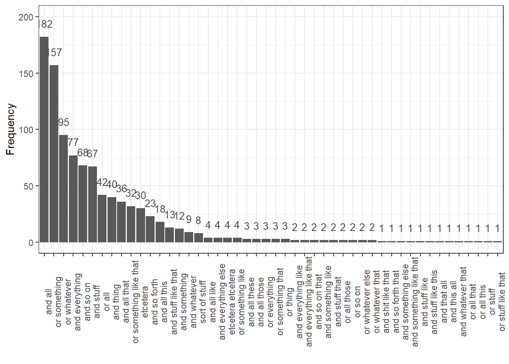

```r
genex %>%
  dplyr::arrange(-n) %>%
  ggplot(aes(x = reorder(genex, -n), y = n, label = n)) +
  geom_bar(stat = "identity") +
  geom_text(vjust=-1.2, color = "gray30", size = 3.5) +
  labs(x = "", y = "Frequency") +
  theme_bw() +
  theme(axis.text.x = element_text(angle=90)) +
  coord_cartesian(y = c(0, 200))
```

```r
# save plot
ggsave(here::here("images", "ngenex.png"), unit = "cm", width = 25)
```

```r
clps <- genex %>%
  dplyr::filter(n < 5) %>%
  dplyr::pull(genex)
# inspect
clps
```

```
##  [1] "and all like"             "and all these"
##  [3] "and all those"            "and everything else"
##  [5] "and everything like"      "and everything like that"
##  [7] "and shit like that"       "and so forth that"
##  [9] "and so on that"           "and something else"
## [11] "and something like"       "and something like that"
## [13] "and stuff like"           "and stuff like this"
## [15] "and stuff that"           "and that all"
## [17] "and this all"             "and whatever that"
## [19] "etcetera etcetera"        "or all that"
## [21] "or all this"              "or all those"
## [23] "or everything"            "or so on"
## [25] "or something like"        "or something that"
## [27] "or stuff"                 "or stuff like that"
## [29] "or thing"                 "or whatever else"
## [31] "or whatever that"
```

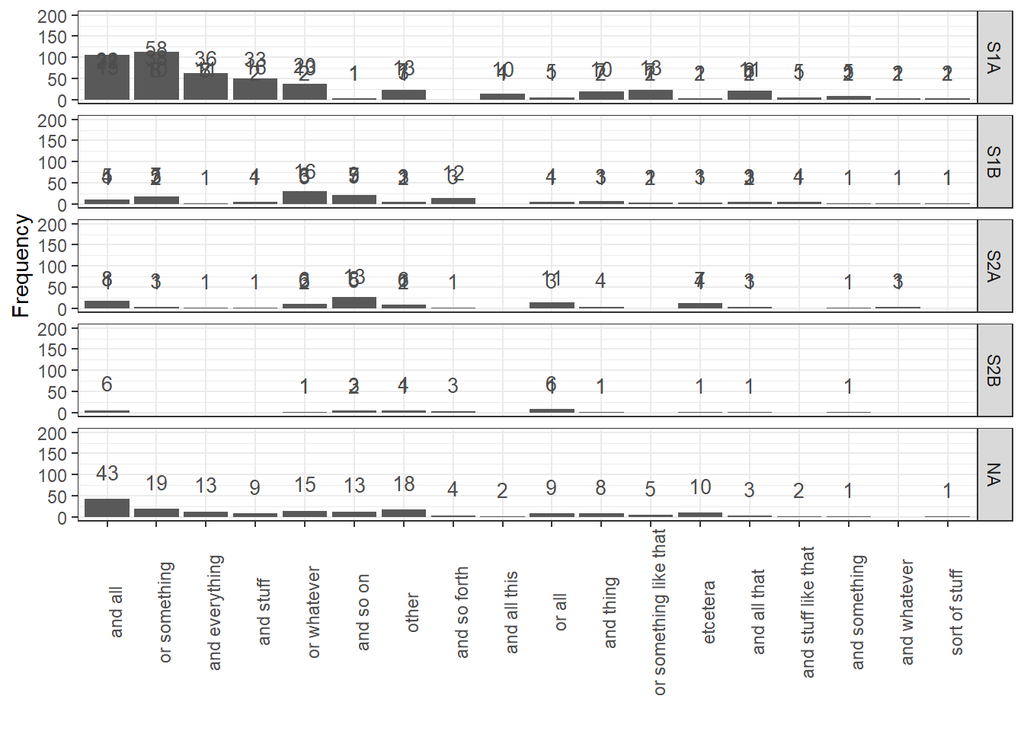

```r
gx_genre <- ireb %>%
  dplyr::filter(gx != "0") %>%
  dplyr::mutate(gx = ifelse(gx %in% clps, "other", gx)) %>%
  dplyr::group_by(Age, texttype, gx) %>%
  dplyr::summarise(freq = n()) %>%
  dplyr::ungroup() %>%
  dplyr::rename(Genre = texttype,
                GeneralExtender = gx,
                Frequency = freq) %>%
  dplyr::arrange(-Frequency) %>%
  ggplot(aes(x = reorder(GeneralExtender, -Frequency), y = Frequency, label = Frequency)) +
  geom_bar(stat = "identity") +
  geom_text(vjust=-1.2, color = "gray30", size = 3.5) +
    facet_grid(vars(Genre)) +
  labs(x = "", y = "Frequency") +
  theme_bw() +
  theme(axis.text.x = element_text(angle=90)) +
  coord_cartesian(y = c(0, 200))
# inspect
gx_genre
```

```r
# save plot
ggsave(here::here("images", "ngx_tt.png"), unit = "cm", width = 25)
```

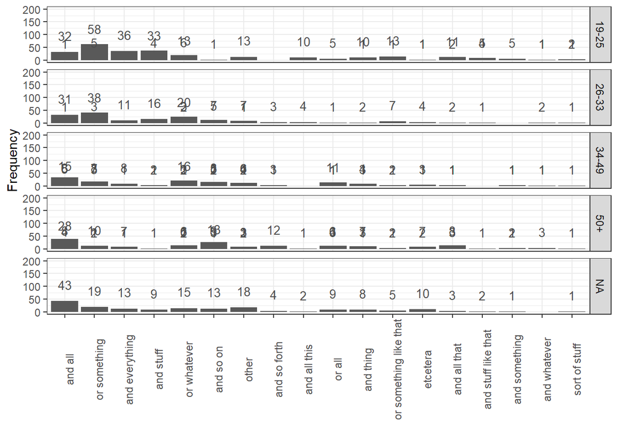

```r
ireb %>%
  dplyr::filter(gx != "0") %>%
  dplyr::mutate(gx = ifelse(gx %in% clps, "other", gx)) %>%
  dplyr::group_by(Age, texttype, gx) %>%
  dplyr::summarise(freq = n()) %>%
  dplyr::ungroup() %>%
  dplyr::rename(Genre = texttype,
                GeneralExtender = gx,
                Frequency = freq) %>%
  dplyr::arrange(-Frequency) %>%
  ggplot(aes(x = reorder(GeneralExtender, -Frequency), y = Frequency, label = Frequency)) +
  geom_bar(stat = "identity") +
  geom_text(vjust=-1.2, color = "gray30", size = 3.5) +
    facet_grid(vars(Age)) +
  labs(x = "", y = "Frequency") +
  theme_bw() +
  theme(axis.text.x = element_text(angle=90)) +
  coord_cartesian(y = c(0, 200))
```

```r
# save plot
ggsave(here::here("images", "ngx_age.png"), unit = "cm", width = 25)
```

# 7 Simplfy data for analysis

```r
freq_ges <- names(table(ireb$gx))[which(table(ireb$gx) > 40)] %>%
  stringr::str_squish()
# inspect
freq_ges
```

```
## [1] "0"              "and all"        "and everything" "and so on"
## [5] "and stuff"      "or all"         "or something"   "or whatever"
```

```r
irec <- ireb %>%
  dplyr::mutate(ges = dplyr::case_when(gx == "0" ~ "0",
                                       gx %in% freq_ges ~ gx,
                                       TRUE ~ "other"))
# save data to disc
write.table(irec, here::here("tables", "ice_prestats.txt"),
            sep = "\t", row.names = F, col.names = T)
# inspect
head(irec)
```

```
## # A tibble: 6 × 25
## # Rowwise:
##   File    Speaker Su               Su_clean    Id Wordsunit FileSpeakerId Region
##   <chr>   <chr>   <chr>            <chr>    <int>     <int> <chr>         <chr>
## 1 S1A-001 A       Well how did th… well ho…     1         7 <S1A-001$A>   North…
## 2 S1A-001 B       It was good so … it was …     2         6 <S1A-001$B>   North…
## 3 S1A-001 B       Just I I couldn… just i …     3        22 <S1A-001$B>   North…
## 4 S1A-001 B       It was great <&… it was …     4         3 <S1A-001$B>   North…
## 5 S1A-001 A       What did you ca… what di…     5         6 <S1A-001$A>   North…
## 6 S1A-001 B       I can't remember i can't…     6         4 <S1A-001$B>   North…
## # … with 17 more variables: DateOfRecording <chr>, Gender <chr>, Age <chr>,
## #   ChildhoodCounty <chr>, ResidenceType <chr>, Education <chr>,
## #   Occupation <chr>, ReligiousAffiliation <chr>, SpeechUnits <int>,
## #   Words <int>, texttype <chr>, AudienceSize <chr>, ConversationType <chr>,
## #   ngenex <dbl>, nsu <chr>, gx <chr>, ges <chr>
```

# 8 Statistical Analysis

load packages

```r
library(Boruta)
library(ggparty)
library(party)
library(partykit)
library(cfa)
```

Prepare data

```r
# create vector of variables to keep
keep <-c("File", "Speaker", "Id", "Wordsunit",  "Region", "DateOfRecording",
         "Gender", "Age", "ChildhoodCounty", "ResidenceType", "Education",
         "Occupation", "ReligiousAffiliation", "texttype", "AudienceSize",
         "ConversationType", "ngenex",  "gx", "ges")
# simplify data
dstat <- irec %>%
  dplyr::select(keep) %>%
  dplyr::rename(nge = ngenex,
                ge = gx) %>%
  dplyr::mutate(texttype = dplyr::case_when(texttype == "S1A" ~ "Private",
                                            texttype == "S1B" ~ "Public",
                                            texttype == "S2A" ~ "Scripted",
                                            texttype == "S2B" ~ "Unscripted",
                                            TRUE ~ "other"),
                texttype = factor(texttype,
                                  levels = c("Private", "Public",
                                             "Unscripted",  "Scripted")),
                Age = factor(Age, levels = c("19-25", "26-33", "34-49", "50+"))) %>%
  dplyr::mutate_if(is.character, factor)
# inspect
head(dstat)
```

```
## # A tibble: 6 × 19
## # Rowwise:
##   File    Speaker    Id Wordsunit Region          DateOfRecording Gender Age
##   <fct>   <fct>   <int>     <int> <fct>           <fct>           <fct>  <fct>
## 1 S1A-001 A           1         7 NorthernIreland 1990-1994       male   34-49
## 2 S1A-001 B           2         6 NorthernIreland 1990-1994       female 34-49
## 3 S1A-001 B           3        22 NorthernIreland 1990-1994       female 34-49
## 4 S1A-001 B           4         3 NorthernIreland 1990-1994       female 34-49
## 5 S1A-001 A           5         6 NorthernIreland 1990-1994       male   34-49
## 6 S1A-001 B           6         4 NorthernIreland 1990-1994       female 34-49
## # … with 11 more variables: ChildhoodCounty <fct>, ResidenceType <fct>,
## #   Education <fct>, Occupation <fct>, ReligiousAffiliation <fct>,
## #   texttype <fct>, AudienceSize <fct>, ConversationType <fct>, nge <dbl>,
## #   ge <fct>, ges <fct>
```

## 8.1 Data Vis

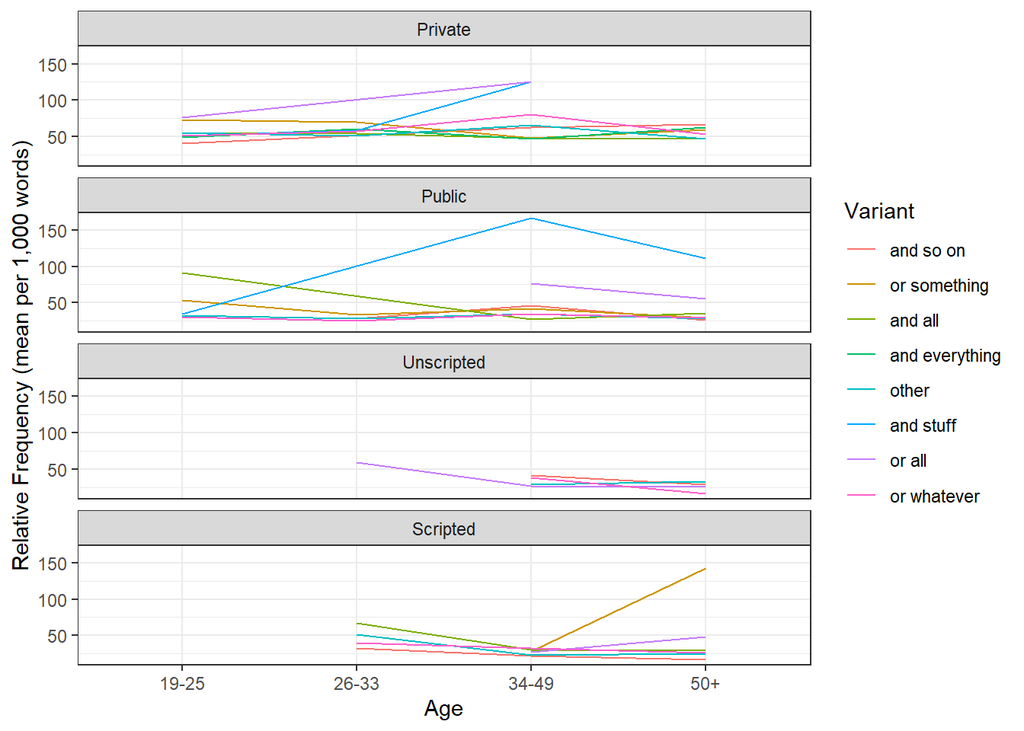

```r
dstat %>%
  dplyr::select(Age, texttype, ges, nge, Wordsunit) %>%
  dplyr::group_by(Age, texttype, ges) %>%
  summarise(words = sum(Wordsunit),
            ns = sum(nge),
            freq = round(ns/words *1000, 3)) %>%
  dplyr::ungroup() %>%
  dplyr::filter(ges != "0") %>%
  dplyr::rename(Variant = ges) %>%
  na.omit() %>%
  ggplot(aes(x = Age, y = freq, group = Variant, color = Variant)) +
  facet_wrap(~texttype, ncol = 1) +
  geom_line() +
  theme_bw() +
  labs(y = "Relative Frequency (mean per 1,000 words)")
```

```r
ggsave(here::here("images", "ge_age_tt.png"), unit = "cm", width = 15)
```

```
## Saving 15 x 12.7 cm image
```

[output not shown]

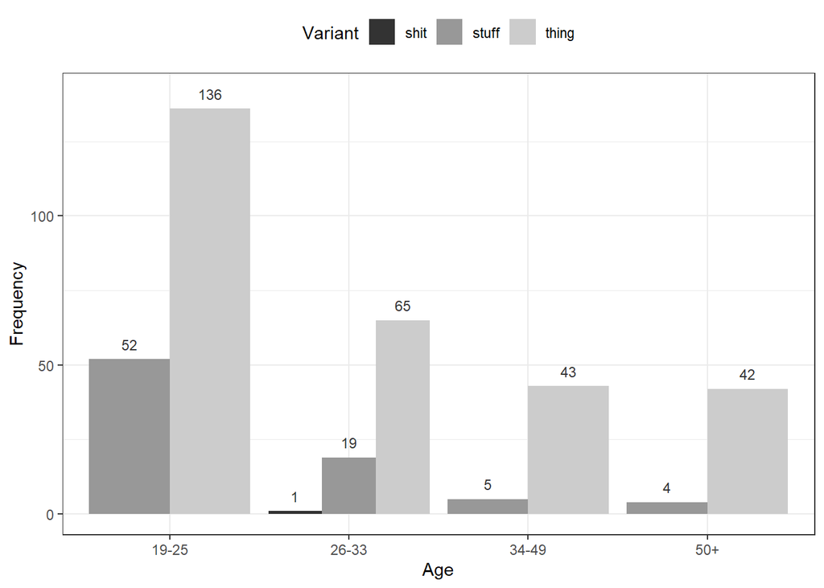

```r
dstat %>%
  dplyr::select(Age, ge) %>%
  dplyr::mutate(Variant = dplyr::case_when(str_detect(ge, "stuff") ~ "stuff",
                                         str_detect(ge, "shit") ~ "shit",
                                         str_detect(ge, "thing") ~ "thing",
                                         TRUE ~ "other")) %>%
  dplyr::filter(Variant != "other") %>%
  dplyr::group_by(Age, Variant) %>%
  summarise(Frequency = n()) %>%
  dplyr::ungroup() %>%
  na.omit() %>%
  ggplot(aes(x = Age, y = Frequency, group = Variant, fill = Variant)) +
  geom_bar(stat = "identity", position = position_dodge()) +
  theme_bw() +
  geom_text(aes(y = Frequency + 5, label = Frequency),
            color = "gray20", position = position_dodge(0.9), size=3) +
  scale_fill_grey() +
  theme(legend.position = "top")
```

```r
ggsave(here::here("images", "ge_age_stuff.png"), unit = "cm", width = 10)
```

```
## Saving 10 x 12.7 cm image
```

## 8.2 Bortuta

Prepare data

```r
citdata <- dstat %>%
  dplyr::rename(Texttype = texttype,
                Occurrence = nge,
                GeneralExtender = ge,
                Variant = ges) %>%
  dplyr::filter(Variant != "0") %>%
  dplyr::mutate(FileSpeaker = paste0(File, "$", Speaker, sep = "")) %>%
  dplyr::select(-Id, -Wordsunit, -GeneralExtender, -File, -Speaker,
                -Occurrence, -ChildhoodCounty, -Occupation) %>%
  dplyr::mutate(Variant = droplevels.factor(Variant),
      Region = dplyr::case_when(Region == "NorthernIreland" ~ "NI",
                                Region == "RepublicOfIreland" ~ "RoI",
                                Region == "Interstate" ~ "Mixed",
                                TRUE ~ "NA")) %>%
  dplyr::mutate_if(is.character, factor) %>%
  dplyr::filter(Texttype == "Private")
# inspect
head(citdata)
```

```
## # A tibble: 6 × 12
## # Rowwise:
##   Region DateOfRecording Gender Age   ResidenceType Education ReligiousAffiliat…
##   <fct>  <fct>           <fct>  <fct> <fct>         <fct>     <fct>
## 1 NI     1990-1994       female 34-49 Urban         NoCollege Protestant
## 2 NI     1990-1994       male   34-49 Urban         College   Protestant
## 3 NI     1990-1994       female 34-49 Urban         NoCollege Protestant
## 4 NI     1990-1994       female 34-49 Urban         NoCollege Protestant
## 5 NI     1990-1994       male   34-49 Urban         College   Protestant
## 6 NI     2002-2005       female 50+   Urban         NoCollege Catholic
## # … with 5 more variables: Texttype <fct>, AudienceSize <fct>,
## #   ConversationType <fct>, Variant <fct>, FileSpeaker <fct>
```

```r
check <- citdata[complete.cases(citdata),]
nrow(citdata); nrow(check)
```

```
## [1] 507
```

```
## [1] 360
```

```r
# checks
sum(table(citdata$Region))
```

```
## [1] 507
```

```r
sum(table(citdata$DateOfRecording)) # problem
```

```
## [1] 507
```

```r
sum(table(citdata$Gender))
```

```
## [1] 507
```

```r
sum(table(citdata$Age))
```

```
## [1] 507
```

```r
sum(table(citdata$ResidenceType)) # problem
```

```
## [1] 432
```

```r
sum(table(citdata$Education)) # problem
```

```
## [1] 486
```

```r
sum(table(citdata$ReligiousAffiliation)) # problem
```

```
## [1] 392
```

```r
sum(table(citdata$Texttype))
```

```
## [1] 507
```

```r
sum(table(citdata$AudienceSize))
```

```
## [1] 507
```

```r
sum(table(citdata$ConversationType))
```

```
## [1] 507
```

```r
sum(table(citdata$Variant))
```

```
## [1] 507
```

```r
sum(table(citdata$FileSpeaker))
```

```
## [1] 507
```

```r
citdata <- citdata %>%
  dplyr::select(-DateOfRecording, -ResidenceType, -Education,
                -ReligiousAffiliation, -Texttype) %>%
  na.omit(.)
# inspect
nrow(citdata)
```

```
## [1] 507
```

```r
# set.seed
set.seed(2019120207)
# initial run
boruta1 <- Boruta(Variant ~., data=citdata)
print(boruta1)
```

```
## Boruta performed 70 iterations in 5.712555 secs.
##  6 attributes confirmed important: Age, AudienceSize, ConversationType,
## FileSpeaker, Gender and 1 more;
##  No attributes deemed unimportant.
```

```r
# extract decision
getConfirmedFormula(boruta1)
```

```
## Variant ~ Region + Gender + Age + AudienceSize + ConversationType +
##     FileSpeaker
## <environment: 0x00000284ba0efac8>
```

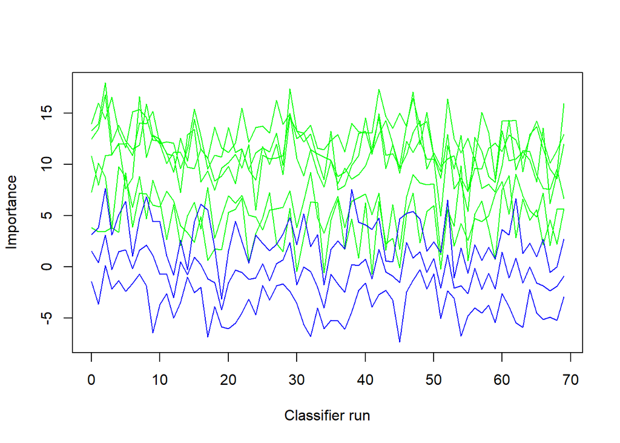

```r
plotImpHistory(boruta1)
```

## 8.3 CIT

Perform CIT analysis

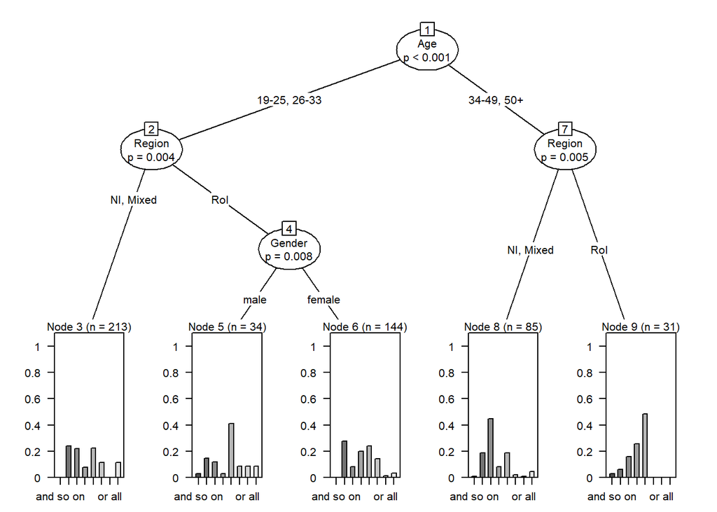

```r
set.seed(111)        # set.seed
# apply bonferroni correction (1 minus alpha multiplied by n of predictors)
control = ctree_control(mincriterion = 1-(.05*ncol(citdata)-1))
# create initial conditional inference tree model
citd.ctree <- partykit::ctree(Variant ~ Region + Gender + Age + AudienceSize,
                    data = citdata)
plot(citd.ctree, gp = gpar(fontsize = 8)) # plot final ctree
```

save plot

```r
png(here::here("images", "cit_base.png"), width = 1200)
plot(citd.ctree, gp = gpar(fontsize = 14))
dev.off()
```

pretty plot

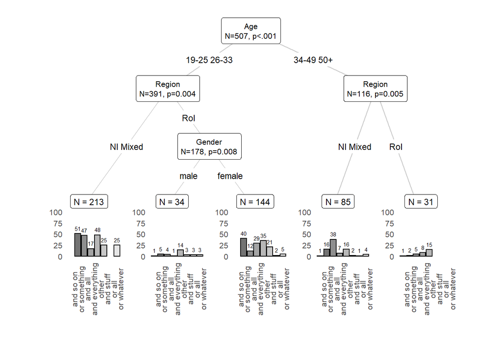

```r
# extract p-values
pvals <- unlist(nodeapply(citd.ctree, ids = nodeids(citd.ctree), function(n) info_node(n)$p.value))
pvals <- pvals[pvals <.05]
# plotting
pcit_freq <- ggparty(citd.ctree) +
  geom_edge(size = .5, col = "gray80") +
  geom_edge_label(size = 3) +
  geom_node_label(line_list = list(aes(label = splitvar, size = 5),
                                   aes(label = paste0("N=", nodesize, ", p",
                                                 ifelse(pvals < .001, "<.001",
                                                   paste0("=", round(pvals, 3)))))),
                  line_gpar = list(list(size = 8),
                                   list(size = 8)),
                  ids = "inner") +
  geom_node_label(aes(label = paste0("N = ", nodesize)),
                  ids = "terminal",
                  nudge_y = 0.01,
                  nudge_x = 0.01,
                  size = 3) +
  geom_node_plot(gglist = list(
    geom_bar(aes(x = Variant, fill = Variant),
             position = position_dodge(), color = "black"),
    theme_minimal(),
    theme(panel.grid.major = element_blank(),
          panel.grid.minor = element_blank(),
          axis.text.x = element_text(angle = 90, size = 8),
          axis.text.y = element_text(size = 8)),
      scale_fill_manual(values = gray.colors(length(names(table(citdata$Variant)))),
                        guide = F),
      scale_y_continuous(breaks = seq(0, 100, 25),
                         limits = c(0, 100)),
    labs(x = "", y = ""),
      geom_text(aes(x = Variant, group = Variant,
                    label = stat(count)),
                stat = "count",
                size = 2,
                position = position_dodge(0.9), vjust = -0.7)),
    shared_axis_labels = TRUE)
# save plot ggsave
ggsave(plot = pcit_freq, here::here("images", "cit_pfreq.png"),
       unit = "cm", width = 20, height = 15)
# show plot
pcit_freq
```

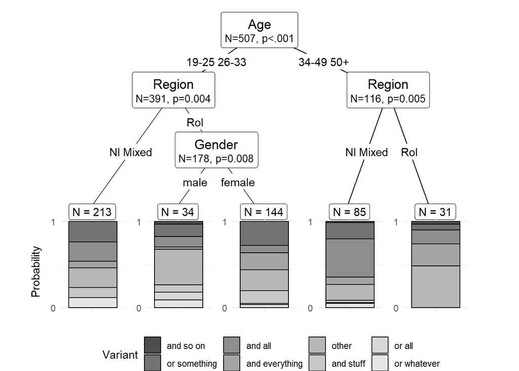

```r
# extract p-values
pvals <- unlist(nodeapply(citd.ctree, ids = nodeids(citd.ctree), function(n) info_node(n)$p.value))
pvals <- pvals[pvals <.05]
# plotting
pcit_stack <- ggparty(citd.ctree) +
  geom_edge() +
  geom_edge_label() +
  geom_node_label(line_list = list(aes(label = splitvar),
                                   aes(label = paste0("N=", nodesize, ", p",
                                                      ifelse(pvals < .001, "<.001", paste0("=", round(pvals, 3)))),
                                       size = 10)),
                  line_gpar = list(list(size = 13),
                                   list(size = 10)),
                  ids = "inner") +
  geom_node_label(aes(label = paste0("N = ", nodesize)),
    ids = "terminal", nudge_y = -0.0, nudge_x = 0.01) +
  geom_node_plot(gglist = list(
    geom_bar(aes(x = "", fill = Variant),
             position = position_fill(),
             color = "black"),
      theme_minimal(),
      scale_fill_manual(values = gray.colors(length(table(citdata$Variant)))),
      scale_y_continuous(breaks = c(0, 1)),
    xlab(""),
    ylab("Probability"),
    geom_text(aes(x = "", group = Variant,
                  label = ""),
              stat = "count", position = position_fill(), vjust = 1.1)),
    shared_axis_labels = TRUE)
# save plot ggsave
ggsave(plot = pcit_stack, here::here("images", "cit_pfreq.png"),
       unit = "cm", width = 20, height = 15)
# show plot
pcit_stack
```

## 8.4 CFA

```r
# prepare data
cfadata <- citdata %>%
  dplyr::group_by(Region, Gender, Variant) %>%
  dplyr::summarise(Frequency = n())
# define configurations
configs <- cfadata %>%
  dplyr::select(Region, Gender, Variant)
# define counts
counts <- cfadata$Frequency
# perform cfa
cfares <- cfa(configs, counts)
cfasig <- cfares$table %>%
  as.data.frame() %>%
  dplyr::filter(sig.z == T)
# save
write.table(cfasig, here::here("tables", "sigcfa.txt"), sep = "\t")
# inspect
cfasig
```

```
##                         label  n   expected           Q     chisq   p.chisq
## 1 RoI   male   or all          3  0.5561430 0.004825524 10.739031 0.7064046
## 2 RoI   male   and so on       2  0.2780715 0.003398172 10.662861 0.7122943
## 3 Mixed female or whatever     8  2.8284491 0.010257522  9.455691 0.8007990
## 4 RoI   female and all        16 33.8710596 0.037772070  9.429134 0.8026175
##   sig.chisq        z          p.z sig.z
## 1     FALSE 3.277046 0.0005244961  TRUE
## 2     FALSE 3.265404 0.0005465409  TRUE
## 3     FALSE 3.075011 0.0010524751  TRUE
## 4     FALSE 3.070690 0.0010678254  TRUE
```

# Outro

We have reached the end of part 1 of the analysis.